# Lab 1: Opportunity Zones

Author

Amira Ravshanova

### Section 1

```r
library(tidyverse)
library(DataExplorer)

data <- read_csv("oz_analysis.csv")

data <- data |>
  mutate(DesignatedOZ =
           ifelse(is.na(DesignatedOZ),
                  "Not Designated", "Designated"))

ozs <- data |>
  filter(Type != "Not Eligible")
```

```r
ozs |>
  group_by(county, DesignatedOZ) |>
  summarise(
    Income = median(medhhincome, na.rm=TRUE))
```

```
# A tibble: 25 × 3
# Groups:   county [13]
   county            DesignatedOZ   Income
   <chr>             <chr>           <dbl>
 1 Barnstable County Designated     44620
 2 Barnstable County Not Designated 63026.
 3 Berkshire County  Designated     33897
 4 Berkshire County  Not Designated 53365
 5 Bristol County    Designated     31906.
 6 Bristol County    Not Designated 40788
 7 Dukes County      Not Designated 46816
 8 Essex County      Designated     39875
 9 Essex County      Not Designated 49842.
10 Franklin County   Designated     37308
# ℹ 15 more rows
```

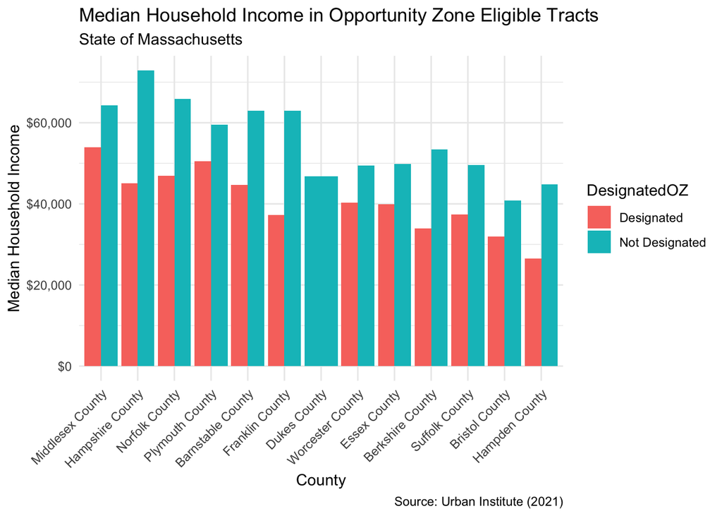

```r
ozs |>
  group_by(county, DesignatedOZ) |>
  summarise(
    Income = median(medhhincome, na.rm=TRUE)) |>
  ggplot(aes(x = reorder(county, -Income), y = Income, fill = DesignatedOZ)) +
  geom_col(position = "dodge") +
  scale_y_continuous(labels = scales::dollar) +
  labs(x = "County",
       y = "Median Household Income",
       title = "Median Household Income in Opportunity Zone Eligible Tracts",
       subtitle = "State of Massachusetts",
       caption = "Source: Urban Institute (2021)") +
  theme_minimal() +
  theme(axis.text.x = element_text(angle = 45, hjust = 1))
```

In every county except Dukes, designated tracts have a lower median household income than eligible tracts that were not designated. The gap varies a lot by county. It is largest in Hampshire and Franklin, and smallest in Bristol and Plymouth. Dukes County shows only one bar because none of its eligible tracts were designated.

### Section 2

```r
income_diff <- ozs |>
  group_by(county, DesignatedOZ) |>
  summarise(Income = median(medhhincome, na.rm = TRUE)) |>
  pivot_wider(names_from = DesignatedOZ, values_from = Income) |>
  mutate(Difference = `Not Designated` - Designated)

income_diff |>
  arrange(desc(Difference))
```

```
# A tibble: 13 × 4
# Groups:   county [13]
   county            Designated `Not Designated` Difference
   <chr>                  <dbl>            <dbl>      <dbl>
 1 Hampshire County      45108.           72886      27778.
 2 Franklin County       37308            62986.     25678.
 3 Berkshire County      33897            53365      19468
 4 Norfolk County        46947            65845      18898
 5 Barnstable County     44620            63026.     18406.
 6 Hampden County        26507            44751      18244
 7 Suffolk County        37364.           49559      12194.
 8 Middlesex County      53894            64286.     10392.
 9 Essex County          39875            49842.      9966.
10 Worcester County      40312            49464       9152
11 Plymouth County       50549            59545       8996
12 Bristol County        31906.           40788       8882.
13 Dukes County             NA            46816         NA
```

Hampshire County has the greatest disparity in median household income between designated and non-designated tracts.

Dukes County shows NA because none of its eligible tracts were designated, so there is no designated median to subtract. I left it as NA instead of making it 0, since 0 would falsely suggest the two groups had equal incomes.

### Section 3

#### Part 1

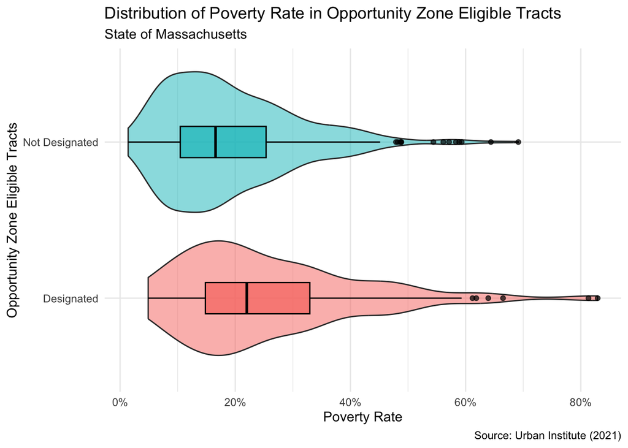

```r
ozs |>
  ggplot(aes(x = DesignatedOZ, y = PovertyRate, fill = DesignatedOZ)) +
  geom_violin(trim = TRUE, alpha = 0.5) +
  geom_boxplot(width = 0.2, color = "black", alpha = 0.7) +
  scale_y_continuous(labels = scales::percent) +
  labs(x = "Opportunity Zone Eligible Tracts",
       y = "Poverty Rate",
       title = "Distribution of Poverty Rate in Opportunity Zone Eligible Tracts",
       subtitle = "State of Massachusetts",
       caption = "Source: Urban Institute (2021)") +
  coord_flip() +
  theme_minimal() +
  theme(legend.position = "none")
```

The two distributions overlap a lot, but designated tracts tend to have higher poverty rates than non-designated tracts.

#### Part 2

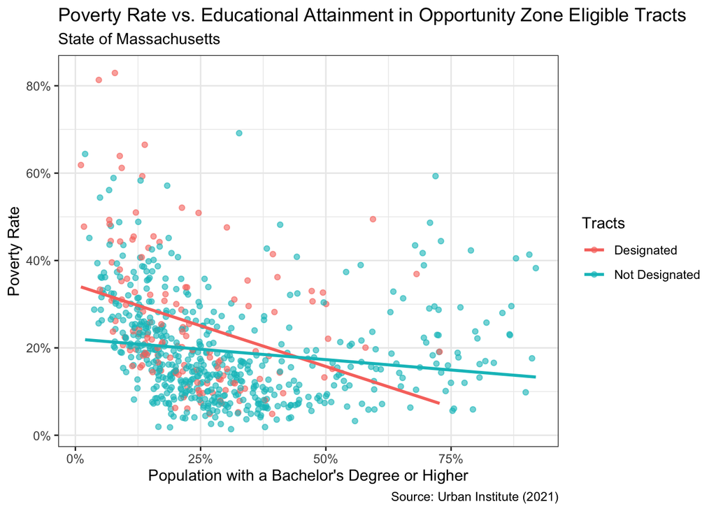

```r
ozs |>
  ggplot(aes(x = BAorhigher, y = PovertyRate, color = DesignatedOZ)) +
  geom_point(alpha = 0.6) +
  geom_smooth(method = "lm", se = FALSE) +
  scale_x_continuous(labels = scales::percent) +
  scale_y_continuous(labels = scales::percent) +
  labs(x = "Population with a Bachelor's Degree or Higher",
       y = "Poverty Rate",
       color = "Tracts",
       title = "Poverty Rate vs. Educational Attainment in Opportunity Zone Eligible Tracts",
       subtitle = "State of Massachusetts",
       caption = "Source: Urban Institute (2021)") +
  theme_bw()
```

Poverty rate and educational attainment show a negative relationship where tracts with a higher share of residents holding a bachelor’s degree tend to have lower poverty rates. The relationship is steeper in designated tracts than non-designated tracts.

The flatter line for non-designated tracts is pulled by a cluster of tracts with both high education (60–90% with a BA) and high poverty (30–60%). These are probably neighborhoods with large college student populations like Cambridge or Boston because students usually report low incomes, which raises the measured poverty rate even though residents are highly educated.

#### Part 3

**Question 1: Why were some eligible tracts chosen over others?** Designated tracts were poorer on average but in counties like Hampshire and Franklin the gap was very large, and some higher-income tracts were designated while poorer ones were not. I would want to know what other factors shaped the governor’s choices. Helpful data would include tract boundaries (to map proximity to downtowns, universities, transit, etc.) and records of pre-2018 development activity like building permits or planned projects.

**Question 2: Did designation change these neighborhoods and who benefited?** Critics argue OZ investment can lead to displacement. To test this, I would compare how designated and eligible but not designated tracts changed after 2018. This would require newer Census/ACS data on income, rent, rent burden, and racial composition, as well as data on where OZ funds actually invested, property sales, and eviction records.